# Add your Name: AASHI AGGARWAL

# StudentID: 8920299

# Please submit the notebook and HTML version of your notebook to EConestoga Dropbox

# **Question 1 - Pandas** (12 marks)

- Using RegularSeasonCompactResults.csv
- and Teams.csv

```python
import pandas as pd
```

```python
# Using RegularSeasonCompactResults.csv
# 1- Create a filter to show if there are any draw matches
# 2- Apply the filter to the dataframe
# 3- SHOW the dataframe length or count (4 marks)
## TODO: Your code should be here


df = pd.read_csv('RegularSeasonCompactResults.csv')

def is_draw(row):
    return row['Wscore'] == row['Lscore']


draw_matches = df[df.apply(is_draw, axis=1)]


draw_match_count = len(draw_matches)
print("Number of draw matches:", draw_match_count)
```

```
Number of draw matches: 0
```

```python
# Using RegularSeasonCompactResults.csv
# 1- Create a filter showing the entries where the winningteamID= 1400- (last two digits of your id)
# 2- Create another filter for the season of 2013
# 3- Apply the filter to the dataframe
# 4- Show the resulted dataframe (4 marks)
# (Example: IF your id is 8000021, the winning team id = 1400-21= 1389)
# TODO: Your code should be here

# Load the dataset
df = pd.read_csv('RegularSeasonCompactResults.csv')

# Create a filter showing the entries where the winningteamID= 1400- (last two digits of your id)

target_team_id = 1400 - 99

# filter for winning team ID
winning_team_filter = df['Wteam'] == target_team_id

# filter for the season of 2013
season_filter = df['Season'] == 2013

# Applying filters to the DataFrame
filtered_df = df[winning_team_filter & season_filter]
print(filtered_df)
```

```
        Season  Daynum  Wteam  Wscore  Lteam  Lscore Wloc  Numot
123936    2013       4   1301      97   1275      59    H      0
124180    2013      10   1301      72   1336      55    N      0
124238    2013      11   1301      94   1269      76    N      0
124584    2013      18   1301      82   1421      80    H      0
125039    2013      29   1301      69   1163      65    N      0
125192    2013      33   1301      80   1156      63    H      0
125348    2013      40   1301      84   1313      62    H      0
125456    2013      43   1301      88   1390      79    H      0
125646    2013      47   1301      92   1382      73    H      0
125804    2013      54   1301      84   1444      68    H      0
125887    2013      56   1301      89   1422      68    H      0
126108    2013      61   1301      78   1130      73    A      0
126254    2013      65   1301      83   1210      70    H      0
126423    2013      68   1301      84   1181      76    H      0
126824    2013      76   1301      66   1155      62    H      0
127069    2013      82   1301      91   1314      83    H      0
127785    2013      97   1301      58   1155      57    A      0
128038    2013     103   1301      90   1439      86    H      1
128157    2013     106   1301      84   1199      66    H      0
128489    2013     114   1301      82   1130      64    H      0
128739    2013     118   1301      70   1210      57    A      0
128806    2013     121   1301      81   1448      66    H      0
129109    2013     129   1301      80   1439      63    N      0
129155    2013     130   1301      75   1438      56    N      0
```

```python
# Using RegularSeasonCompactResults.csv & Teams.csv
# 1- Load and merge both dataframes
# 2- Where the merge is on WinningTeamId (RegularSeasonCompactResults) and TeamId (Teams.csv)
# 3- Name the dataframe: DFCombined
# 4- Show the top 3 rows (4 marks)
# TODO: Your code should be here

regular_season_df = pd.read_csv('RegularSeasonCompactResults.csv')
teams_df = pd.read_csv('Teams.csv')

# Merging
DFCombined = regular_season_df.merge(teams_df, left_on='Wteam', right_on='Team_Id', how='inner')

# Show the top 3 rows of the combined DataFrame
top_3_rows = DFCombined.head(3)
print(top_3_rows)
```

```
   Season  Daynum  Wteam  Wscore  Lteam  Lscore Wloc  Numot  Team_Id Team_Name
0    1985      20   1228      81   1328      64    N      0     1228  Illinois
1    1985      25   1228      64   1226      44    N      0     1228  Illinois
2    1985      27   1228      75   1332      72    N      3     1228  Illinois
```

# **Question 2 - Visualizations**

## **Part I**

Using the following dataset: https://raw.githubusercontent.com/mwaskom/seaborn-data/master/penguins.csv choose the most convenient graph to show the following, each question in **one** graph, using the library of your choice: (18 Marks)

**1. .** (5 marks)The relationship between the penguin's bill length and bill depth for each species

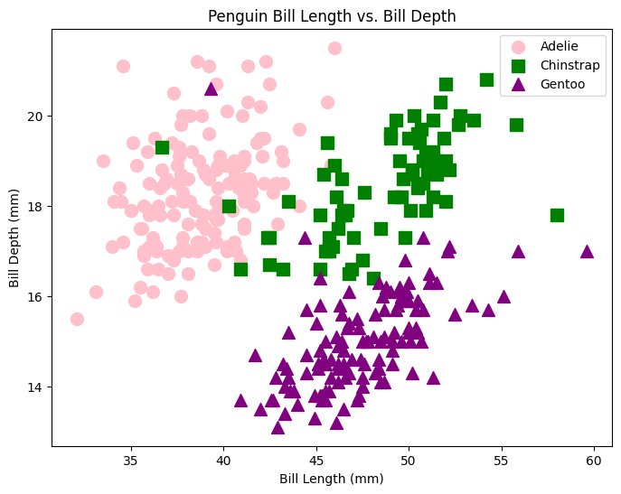

```python
## TODO: Check your attributes, make a graph using Matplotlib or Seaborn to show the relationship needed
#pyplot  bargraph
#bargraph best for relationship fits
import pandas as pd
import matplotlib.pyplot as plt

# Load the penguins.csv file into a DataFrame
df = pd.read_csv("penguins.csv")

# Create separate DataFrames for each species
adelie_data = df[df['species'] == 'Adelie']
chinstrap_data = df[df['species'] == 'Chinstrap']
gentoo_data = df[df['species'] == 'Gentoo']

# Create a scatterplot with all three species
plt.figure(figsize=(8, 6))

# Scatterplot for Adelie penguins
plt.scatter(adelie_data['bill_length_mm'], adelie_data['bill_depth_mm'], c='pink', label='Adelie', marker='o', s=100)

# Scatterplot for Chinstrap penguins
plt.scatter(chinstrap_data['bill_length_mm'], chinstrap_data['bill_depth_mm'], c='green', label='Chinstrap', marker='s', s=100)

# Scatterplot for Gentoo penguins
plt.scatter(gentoo_data['bill_length_mm'], gentoo_data['bill_depth_mm'], c='purple', label='Gentoo', marker='^', s=100)

plt.xlabel('Bill Length (mm)')
plt.ylabel('Bill Depth (mm)')
plt.title('Penguin Bill Length vs. Bill Depth')
plt.legend()

plt.show()
```

**What do you observe from the graph?** (2 marks)

**Why did you choose this type of graph?** (2 marks)

Because it clearly differentiates between the three species. Different colours data points defining each species makes it easier to understand.

Suitable graph of the mean BMI (BMI not body_mass weight_in_kg/height(m2)) of female and male penguins. (Assume the height is the flipper length)

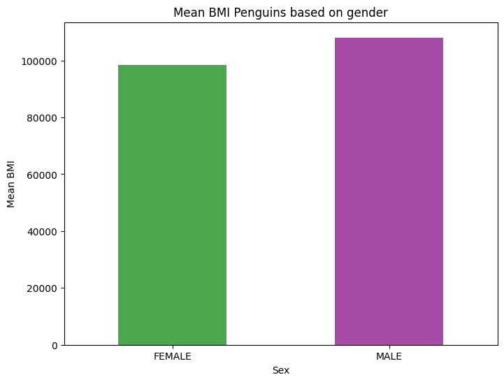

```python
import pandas as pd
import matplotlib.pyplot as plt


df = pd.read_csv("penguins.csv")

df['BMI'] = df['body_mass_g'] / ((df['flipper_length_mm'] / 1000) ** 2)


mean_bmi_by_sex = df.groupby('sex')['BMI'].mean()


plt.figure(figsize=(8, 6))
mean_bmi_by_sex.plot(kind='bar', color=['green', 'purple'], alpha=0.7)
plt.xlabel('Sex')
plt.ylabel('Mean BMI')
plt.title('Mean BMI Penguins based on gender')
plt.xticks(rotation=0)
plt.show()
```

**What do you observe from the graph?** (2 marks)

The bmi of female is smaller than male penguins. there isnt much difference but visible.

**Why did you choose this type of graph?** (2 marks)

Bar graph is the best graph to compare the data. We can easily compare male and female bmi here.*

## **Part II**

You can find the csv file that contains the museum visitors data here: ./CSVs/museum_visitors.csv (8 marks)

Review the data by taking a look at a few of the rows.

Convince the museum board

The Firehouse Museum claims they ran an event in 2014 that brought an incredible number of visitors, and that they should get extra budget to run a similar event again. The other museums think these types of events aren't that important, and budgets should be split purely based on recent visitors on an average day.

To show the museum board how the event compared to regular traffic at each museum, create a suitable chart that shows how the number of visitors to each museum evolved over time. (4 marks)

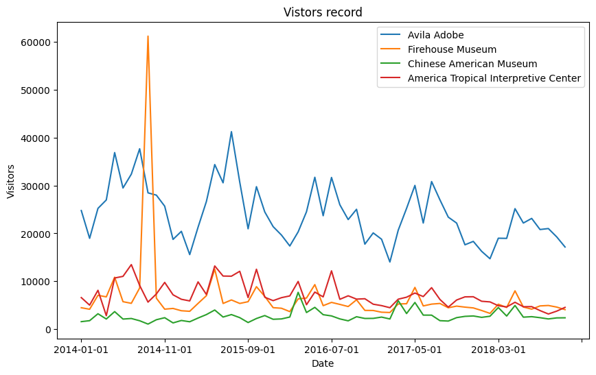

```python
# Your solution here
import pandas as pd
import matplotlib.pyplot as plt

df = pd.read_csv('museum_visitors.csv')

df.set_index('Date', inplace=True)

# line plot
df.plot(kind='line', figsize=(10, 6))

# Set the plot title and axis labels
plt.title('Vistors record')
plt.xlabel('Date')
plt.ylabel('Visitors')

plt.legend()
plt.show()
```

What did you observe from the graph? (2 marks)

Your answer here It is clearly visible that Fire Museum's event was a succesful event and it invited huge number of visitors. In the graph, the highest peak shows 60,000 visitors . *

Why did you choose this type of graph? (2 marks)

As the data is diverse and we need to compare the results based on the event happened, line graph is the best. *

Using the file in ./CSVs/gas_prices.csv  
Use a suitable plot/graph that will show the relationship between the gas price for each country (vs others) over all years. (8 marks)

## **PART III**

First, review the data by taking a look at a few of the rows.

Then Plot using the most suitable plot on your opinion (5 marks)

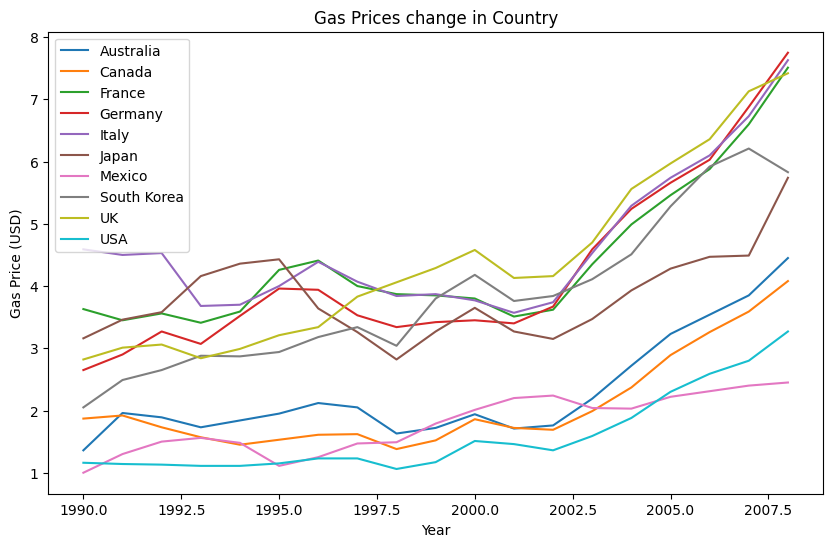

```python
# Your solution here
import pandas as pd
import matplotlib.pyplot as plt

df = pd.read_csv('gas_prices.csv')

df.set_index('Year', inplace=True)

# line plot
df.plot(kind='line', figsize=(10, 6))

# Set the plot title and axis labels
plt.title('Gas Prices change in Country')
plt.xlabel('Year')
plt.ylabel('Gas Price (USD)')

plt.legend()
plt.show()
```

Is there anything interesting observed from the plot/graph? (1 mark)

Why did you choose this type of graph? (2 marks)

Because we need to plot change about each country..